# Nanofish: Motor function

# Set up environment

## Load libraries

## Load functions

## Load data

### Adjust classes and transformations

```
'data.frame':   467 obs. of  30 variables:
 $ StudyID             : Factor w/ 59 levels "2","3","4","5",..: 40 40 50 50 50 50 16 16 16 7 ...
 $ StudyCluster        : Factor w/ 34 levels "1","2","3","5",..: 4 4 5 5 5 5 4 4 4 18 ...
 $ Study               : Factor w/ 59 levels "Ašmonaitė et al., 2020",..: 1 1 2 2 2 2 3 3 3 4 ...
 $ Year                : int  2020 2020 2018 2018 2018 2018 2020 2020 2020 2019 ...
 $ EScluster           : Factor w/ 101 levels "1","2","3","4",..: 1 1 2 2 2 2 3 3 3 4 ...
 $ AdministrationRoute : Factor w/ 6 levels "Food","Injection",..: 1 1 4 4 4 4 1 1 1 4 ...
 $ Concentration_mg_L  : num  NA NA 0.26 0.69 0.26 0.69 NA NA NA 20 ...
 $ ParticleMaterial    : Factor w/ 7 levels "Aminoplast","LDPE",..: 6 3 1 1 1 1 3 3 3 6 ...
 $ Species             : Factor w/ 20 levels "Argyrosomus regius",..: 9 9 8 8 8 8 9 9 9 7 ...
 $ ParticleShape       : Factor w/ 4 levels "Irregular","Sphere",..: 2 2 2 2 2 2 2 2 2 2 ...
 $ Sex                 : Factor w/ 5 levels "F","F:M","FM",..: 5 5 5 5 5 5 5 5 5 NA ...
 $ DevelopmentalStage  : Factor w/ 5 levels "Embrio","Larva",..: 4 4 4 4 4 4 4 4 4 2 ...
 $ ExposureDurationCat : Factor w/ 3 levels "15 days +","5-15 days",..: 2 2 3 3 3 3 1 1 1 3 ...
 $ ExposureDurationDays: int  14 14 4 4 4 4 28 28 28 2 ...
```

[output cut: 16 more lines]

### Calculate Effect Size

```r
df_original <- metafor::escalc(measure = "SMD", n1i = n_treat, n2i = n_ctrl, m1i = mean_treat,
    m2i = mean_ctrl, sd1i = STD_treat, sd2i = STD_ctrl, data = df_original, vtype = "UB")
# write.csv(df_original,file = 'mvMetaAnalysis_SMDs.csv')
```

### Create variables

```r
outcome <- as.character(outcomeslist[[n_outcome]])

mRF <- list()  # random effects formula investigation models
mRE <- list()  # random effects multilevel models
mMR <- list()  # multilevel metaregression models

colormap <- c(Embrio = "khaki", Larva = "lightgreen", Juvenile = "lightskyblue",
    Adult = "salmon", Unclear = "plum", ExposureDurationDays = "cornflowerblue",
    ParticleSizeMean = "chartreuse4", Concentration_mg_L = "#fa0079ff", Aminoplast = "chocolate4",
    LDPE = "#2200faff", PE = "#0089faff", PET = "#00faedff", PLA = "#00fa29ff", PS = "#faf200ff",
    PVC = "#fa9a00ff", `Publication year` = "black", Variance = "navyblue")
```

### Select outcome

```
[1] "Motor function: Distance"
```

|  | StudyID | StudyCluster | Study | Year | EScluster | AdministrationRoute | Concentration_mg_L | ParticleMaterial | Species | ParticleShape | Sex | DevelopmentalStage | ExposureDurationCat | ExposureDurationDays | ParticleSizeRange | ParticleSizeMean | ParticleSizeCat | Outcome | OutcomeCategory | Test_or_Assay | OutcomeVariable | Group | n_of_groups | n_ctrl | mean_ctrl | STD_ctrl | n_treat | mean_treat | STD_treat | … |
| --- | --- | --- | --- | --- | --- | --- | --- | --- | --- | --- | --- | --- | --- | --- | --- | --- | --- | --- | --- | --- | --- | --- | --- | --- | --- | --- | --- | --- | --- | --- |
| 9 | 30 | 5 | Bour et al., 2020 | 2020 | 3 | Food |  | PE | Gasterosteus aculeatus | Sphere | Unclear | Adult | 15 days + | 28 | 27-32 | 29.5 | micro | Motor function: Distance | Motor function | Free swimming test | Distance | MPs | 1 | 19 | 29 | 4.359 | 18 | 28 | 12.728 | … |
| 27 | 48 | 42 | Chae et al., 2018 | 2018 | 7 | Water: Unclear | 5 | PS | Zacco temminckii | Sphere | Unclear | Adult | 5-15 days | 7 | 0.051 | 0.051 | nano | Motor function: Distance | Motor function | Open field test | Distance | Exposure - Z. temminckii | 1 | 3 | 79.466 | 7.877 | 2 | 27.0825 | 15.62211012 | … |
| 28 | 48 | 42 | Chae et al., 2018 | 2018 | 8 | Water: Unclear | 5 | PS | Oryzias sinensis | Sphere | Unclear | Adult | 5-15 days | 7 | 0.051 | 0.051 | nano | Motor function: Distance | Motor function | Open field test | Distance | Exposure - O. sinensis | 1 | 4 | 31.08 | 6.623 | 4 | 47.17075 | 8.127042159 | … |
| 29 | 28 | 1 | Chagas et al., 2021 | 2021 | 9 | Water: Semi-static system | 2.5 | PLA | Danio rerio | Irregular | FM | Adult | 15 days + | 28 | 2.34 | 2.34 | micro | Motor function: Distance | Motor function | Open field test | Distance | BP I (2,5 mg/L) | 2 | 30 | 683.108 | 94.595 | 30 | 667.568 | 155.405 | … |
| 30 | 28 | 1 | Chagas et al., 2021 | 2021 | 9 | Water: Semi-static system | 5 | PLA | Danio rerio | Irregular | FM | Adult | 15 days + | 28 | 2.34 | 2.34 | micro | Motor function: Distance | Motor function | Open field test | Distance | BP II (5 mg/L) | 2 | 30 | 683.108 | 94.595 | 30 | 766.216 | 89.865 | … |
| 49 | 63 | 11 | Chen et al., 2020 | 2020 | 11 | Water: Semi-static system | 1 | PS | Danio rerio | Unclear | F | Adult | 5-15 days | 7 | 5 | 5 | micro | Motor function: Distance | Motor function | Open field test | Distance | MP - female | 1 | 3 | 756.155 | 313.599 | 3 | 1790.739 | 126.026 | … |
| 50 | 63 | 11 | Chen et al., 2020 | 2020 | 12 | Water: Semi-static system | 1 | PS | Danio rerio | Unclear | M | Adult | 5-15 days | 7 | 5 | 5 | micro | Motor function: Distance | Motor function | Open field test | Distance | MP - male | 1 | 3 | 1491.794 | 190.504 | 3 | 1890.387 | 123.095 | … |
| 66 | 85 | 2 | Cormier et al., 2021 | 2021 | 24 | Food |  | PE | Oryzias melastigma | Unclear | F:M | Adult | 15 days + | 120 | 11-13 | 12 | micro | Motor function: Distance | Motor function | Free swimming test | Distance | PE-MP | 1 | 12 | 604.361 | 224.299 | 12 | 526.48 | 211.838 | … |
| 67 | 85 | 2 | Cormier et al., 2021 | 2021 | 25 | Food |  | PVC | Oryzias melastigma | Unclear | F:M | Adult | 15 days + | 120 | 11-13 | 12 | micro | Motor function: Distance | Motor function | Free swimming test | Distance | PVC-MP | 1 | 12 | 573.209 | 113.707 | 12 | 725.857 | 224.299 | … |
| 68 | 85 | 2 | Cormier et al., 2021 | 2021 | 26 | Food |  | PE | Danio rerio | Unclear | F:M | Adult | 15 days + | 120 | 125-250 | 187.5 | micro | Motor function: Distance | Motor function | Free swimming test | Distance | PE-MP | 1 | 12 | 1465.625 | 296.875 | 12 | 1431.25 | 328.125 | … |

[output cut: 13 more lines]

# Exploratory data analysis

## Funnel plot

> Before running any meta-analytic model, it is important to explore the meta-analytic dataset to search for potential outliers that could represent data extraction errors. (Nakagawa et al. 2022)

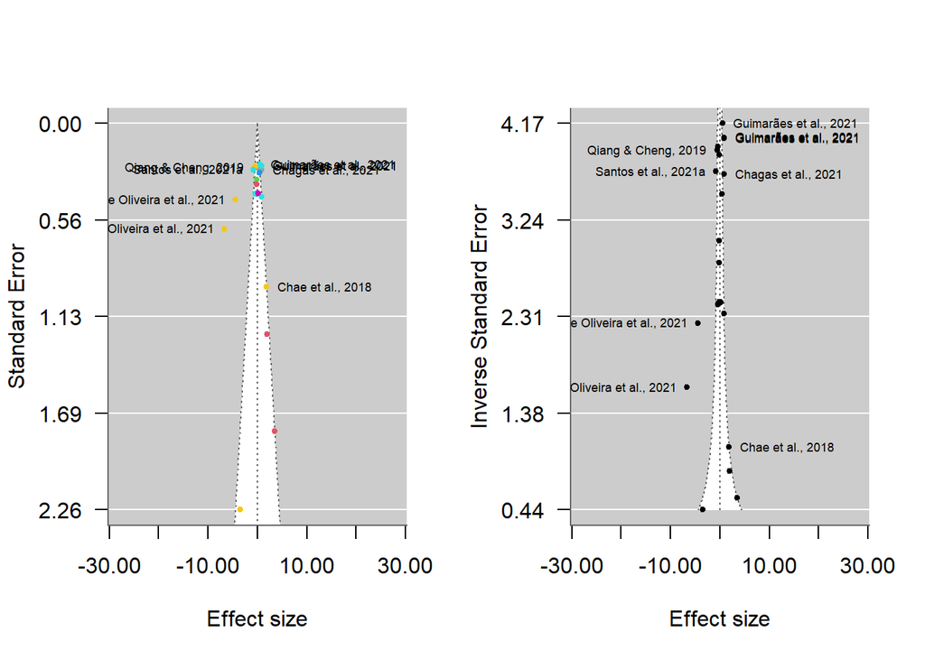

## Alluvial plot

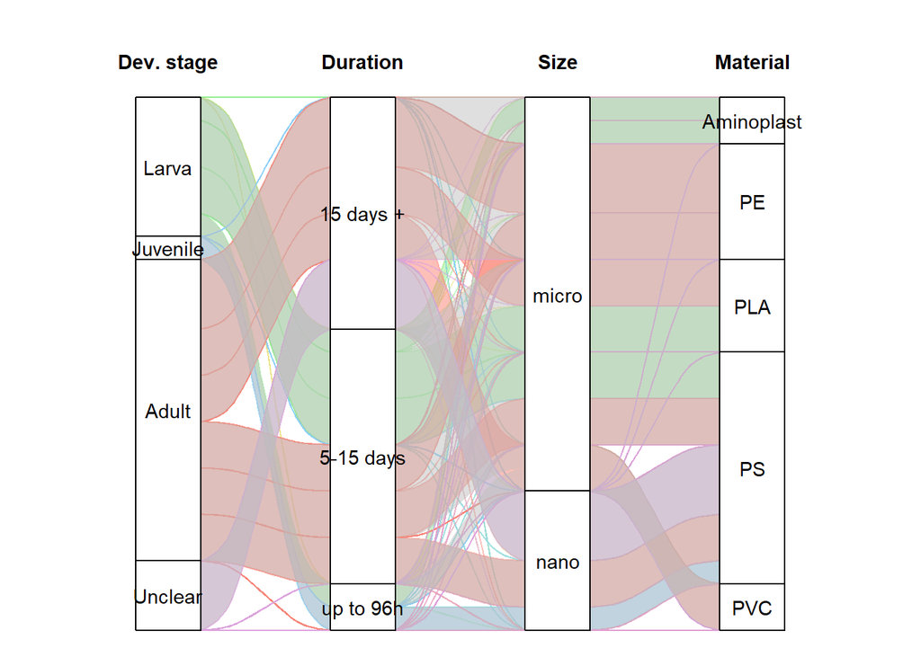

# Multilevel meta-analytic model

## Random effects formula desing

```
[1] "Considering number of studies: 12, number of ES clusters: 17 and number of independent observations of ES: 23, the random effects formula for Motor function: Distance is: ~1 | Study/EScluster/ESid"
```

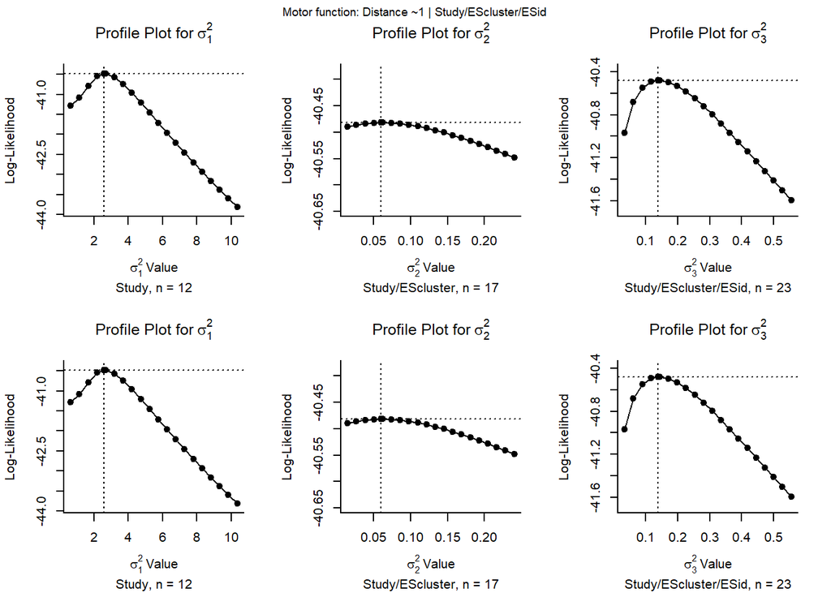

> A profile likelihood plot should show a single peak at the corresponding ML/REML estimate. If `refline=TRUE` (the default), the value of the parameter estimate is indicated by a dotted vertical line and its log-likelihood value by a dotted horizontal line. Hence, the intersection of these two lines should correspond to the peak (assuming that the model was fitted with ML/REML estimation).

> When profiling a variance component (or some other parameter that cannot be negative), the peak may be at zero (if this corresponds to the ML/REML estimate of the parameter). In this case, the profiled log-likelihood should be a monotonically decreasing function of the parameter. Similarly, when profiling a correlation component, the peak may be at -1 or +1.

> If the profiled log-likelihood has multiple peaks, this indicates that the likelihood surface is not unimodal. In such cases, the ML/REML estimate may correspond to a local optimum (when the intersection of the two dotted lines is not at the highest peak).

> If the profile is flat (over the entire parameter space or large portions of it), then this suggests that at least some of the parameters of the model are not identifiable (and the parameter estimates obtained are to some extent arbitrary). See Raue et al. (2009) for some further discussion of parameter identifiability and the use of profile likelihoods to check for this.

> The function checks whether any profiled log-likelihood value is actually larger than the log-likelihood of the fitted model (using a numerical tolerance of `lltol`). If so, a warning is issued as this might indicate that the optimizer did not identify the actual ML/REML estimate of the parameter profiled.[Viechtbauer (2022)](Viechtbauer 2010)

## Additional random effects factors

Study cluster, particle material and species as random effects term can further improve results?

|  | Nested | +StudyCluster | +Particle Material | +Species |
| --- | --- | --- | --- | --- |
| logLik: | -40.48224406092459 | -40.48224406528266 | -40.48224406534992 | -40.4822440661771 |
| deviance: | 77.41226315588756 | 77.4122631646037 | 77.41226316473822 | 77.41226316639259 |
| AIC: | 88.96448812184917 | 90.96448813056531 | 90.96448813069983 | 90.9644881323542 |
| BIC: | 93.50646498556577 | 96.64195921021107 | 96.64195921034559 | 96.64195921199996 |
| AICc: | 91.1867103440714 | 94.4938998952712 | 94.49389989540572 | 94.49389989706009 |

|  | Comparison | LRT | p_value |
| --- | --- | --- | --- |
| 1 | +Study Cluster | 0 | 1 |
| 2 | +Particle Material | 0 | 1 |
| 3 | +Species | 0 | 1 |

## Main result: Multilevel model with $\rho = 0.5$ and robust variance estimate

```r
# Assumed correlation of rho = 0.5, except if there is only one ES by Study (no
# correlation)
if (nES == nSt) {
    VCVrho <- 0
    VCV <- df$vi
} else {
    VCVrho <- 0.5
    VCV <- vcalc(vi, cluster = interaction(df$EScluster, df$Study), obs = ESid, data = df,
        rho = VCVrho)
}

mname1 <- "ML"
mname2 <- paste0(mname1, "_RobVar")

mRE[[mname1]] <- rma.mv(yi, VCV, random = RE_formula, data = df, slab = Study, method = "REML",
    test = "t", dfs = "contain", level = 95)
mRE[[mname1]] <- additional_results(mRE[[mname1]])

mRE[[mname2]] <- robust(mRE[[mname1]], cluster = df$Study, clubSandwich = TRUE)

mRE[[mname2]] <- additional_results(mRE[[mname2]])

I2_ML_RobVar <- i2_ml(mRE[[mname2]])
# I2_ML_RobVar <- i2_ml(mRE[[mname2]], boot = 1000)

extract_report(mRE[[mname2]], outcome, RE_formula)
```

#### Diagnostics plots and results

```
Multivariate Meta-Analysis Model (k = 23; method: REML)

  logLik  Deviance       AIC       BIC      AICc
-39.0879   78.1758   86.1758   90.5400   88.5288

Variance Components:

            estim    sqrt  nlvls  fixed                factor
sigma^2.1  2.7682  1.6638     12     no                 Study
sigma^2.2  0.0000  0.0001     17     no       Study/EScluster
sigma^2.3  0.2516  0.5016     23     no  Study/EScluster/ESid

Test for Heterogeneity:
Q(df = 22) = 211.8721, p-val < .0001

Number of estimates:   23
Number of clusters:    12
Estimates per cluster: 0-4 (mean: 0.39, median: 0)

Model Results:

estimate      se¹     tval¹     df¹    pval¹    ci.lb¹   ci.ub¹
 -0.1994  0.5107   -0.3904   10.91   0.7037   -1.3245   0.9258

---
Signif. codes:  0 '***' 0.001 '**' 0.01 '*' 0.05 '.' 0.1 ' ' 1

1) results based on cluster-robust inference (var-cov estimator: CR2,
   approx t-test and confidence interval, df: Satterthwaite approx)
```

```
[1] 0.917 0.000 0.083
```

```
               I2_Total                I2_Study      I2_Study/EScluster
           9.621708e+01            8.819985e+01            4.285729e-07
I2_Study/EScluster/ESid
           8.017231e+00
```

```
$results
        % of total variance   I2
Level 1        3.782923e+00  ---
Level 2        8.017231e+00 8.02
Level 3        4.285729e-07    0
Level 4        8.819985e+01 88.2

$totalI2
[1] 96.21708

$plot
```

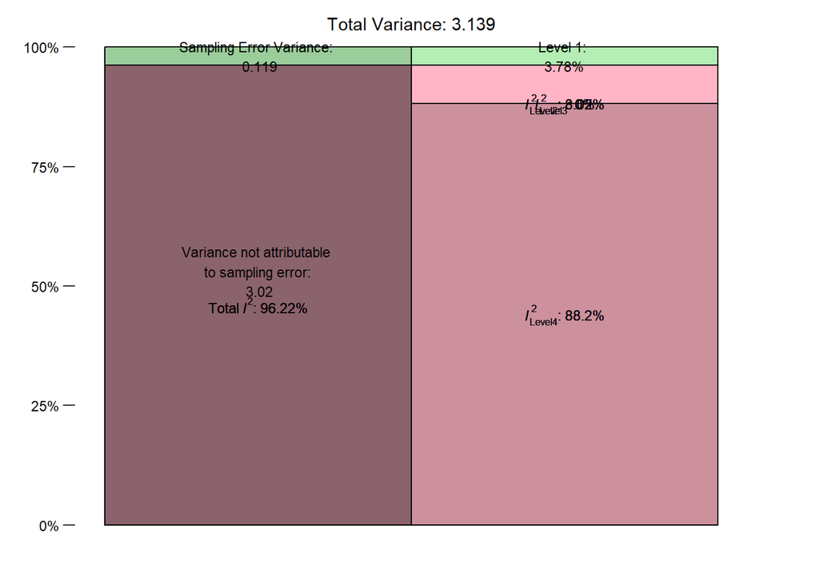

```
attr(,"class")
[1] "mlm.variance.distribution" "list"
```

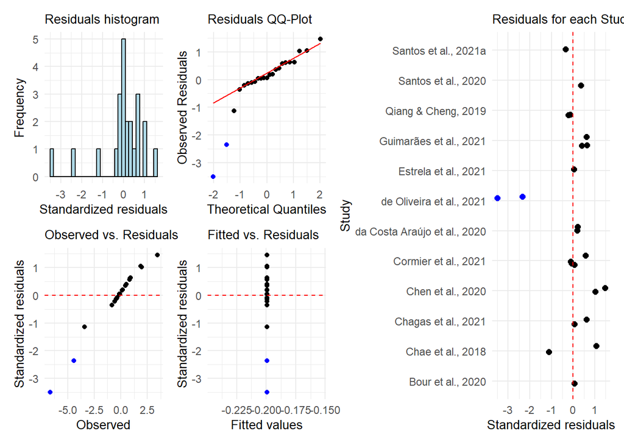

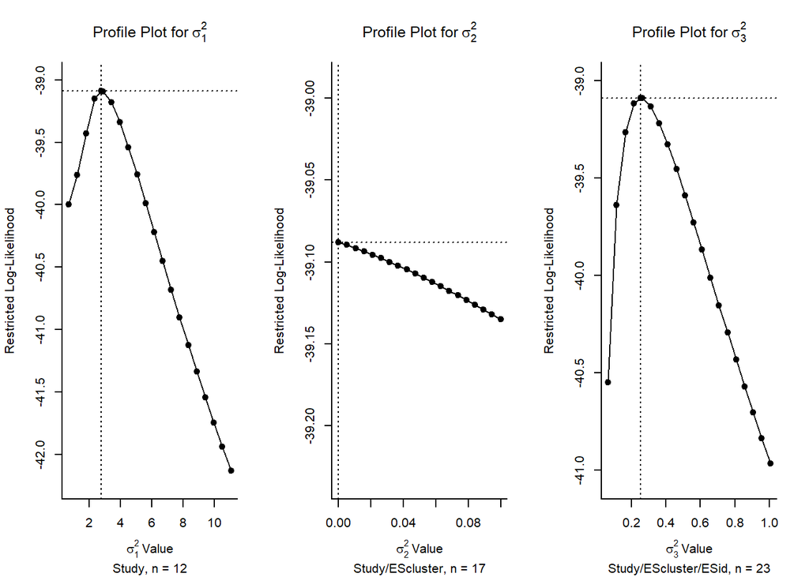

### Forest plot

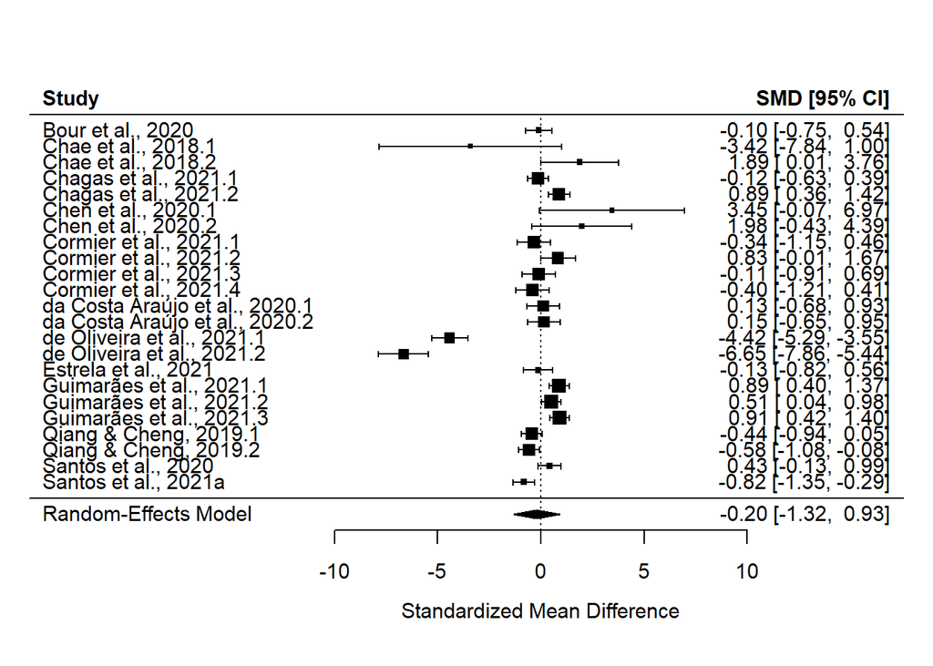

The meta-analysis comprised 23 comparisons from 17 control group clusters of 12 independent studies, so the random formula for Motor function: Distance was ~1 | Study/EScluster/ESid.

No difference between treatment and control groups (ES = -0.199378 ± 0.5106891, CI95% = -1.3245381 to 0.925782, predicted interval -4.1899839 to 3.7912278), with high heterogeneity (i² = 96.22, Q = 211.8720772, p < 0.001 ) and variance explained by each component of $\sigma^2_{Study} = 2.77$, $\sigma^2_{EScluster} = 0.00$, $\sigma^2_{ESid} = 0.25$.

# Publication bias

> **Small-study effect:** when small studies (with small sample sizes) tend to report large effect sizes. (Yang et al. 2023)

> While the PET method works best when the true effect captured by β0β0 is **zero**, PEESE shows a better performance when the true effect is **not** zero. Stanley and Doucouliagos ([2014](https://bookdown.org/MathiasHarrer/Doing_Meta_Analysis_in_R/references.html#ref-stanley2014meta)) therefore proposed to combine both methods, in order to balance out their individual strengths. The resulting approach is the PET-PEESE method. PET-PEESE uses the intercept β0 of either PET or PEESE as the estimate of the corrected true effect.

> Whether PET or PEESE is used depends on the size of the intercept calculated by the PET method. When β0PET is significantly larger than zero in a one-sided test with α = 0.05, we use the intercept of PEESE as the true effect size estimate. If PET’s intercept is not significantly larger than zero, we remain with the PET estimate.

> In most implementations of regression models in *R*, it is conventional to test the significance of coefficients using a two-sided test (i.e. we test if a ββ weight significantly differs from zero, no matter the direction). To assume a one-sided test with α = 0.05, we already regard the intercept as significant when p < 0.1, and when the estimate of β0 is larger than zero<sup>38</sup>. (Harrer et al., n.d.)

> **Time-lag bias:** when statistically significant (“positive” results) tend to be published earlier than those with statistically non-significant findings (“negative” results), leading to a decline in reported effect sizes over time (i.e., a decline effect). (Yang et al. 2023)

> Given that high heterogeneity may invalidate publication bias test, it is best to account for the potential heterogeneity when testing publication bias. (Yang et al. 2023)

> PET-PEESE performs poorly in research areas where there are only a few studies, all studies use small samples, and where there is very high heterogeneity of results from study to study. Nonetheless, the statistical properties of conventional meta-analysis approaches are much worse than PET-PEESE under these same conditions.(Stanley 2017)

So, **better use meta-regression dataset**, but requires larger dataset to avoid possible convergence issues.

#### Plots

```
[1] "PET"
```

```
Multivariate Meta-Analysis Model (k = 23; method: REML)

  logLik  Deviance       AIC       BIC      AICc
-34.1781   68.3562   80.3562   86.3306   86.8178

Variance Components:

            estim    sqrt  nlvls  fixed                factor
sigma^2.1  3.5188  1.8758     12     no                 Study
sigma^2.2  0.0000  0.0001     17     no       Study/EScluster
sigma^2.3  0.2108  0.4592     23     no  Study/EScluster/ESid

Test for Residual Heterogeneity:
QE(df = 20) = 209.2602, p-val < .0001

Number of estimates:   23
Number of clusters:    12
Estimates per cluster: 0-4 (mean: 0.39, median: 0)

Test of Moderators (coefficients 2:3):¹
F(df1 = 2, df2 = 1.58) = 0.4344, p-val = 0.7074

Model Results:

          estimate         se¹     tval¹    df¹    pval¹       ci.lb¹
intrcpt  1742.1427  1558.5356    1.1178   3.24   0.3397   -3019.0373
ESSE       -1.5858     2.6629   -0.5955   1.88   0.6152     -13.7670
Year       -0.8620     0.7711   -1.1179   3.24   0.3396      -3.2172
             ci.ub¹
intrcpt  6503.3227
ESSE       10.5953
Year        1.4931

---
Signif. codes:  0 '***' 0.001 '**' 0.01 '*' 0.05 '.' 0.1 ' ' 1

1) results based on cluster-robust inference (var-cov estimator: CR2,
   approx t/F-tests and confidence intervals, df: Satterthwaite approx)
```

```
 pred   se ci.lb ci.ub pi.lb pi.ub
 0.54 0.95 -1.70  2.78 -4.54  5.62
```

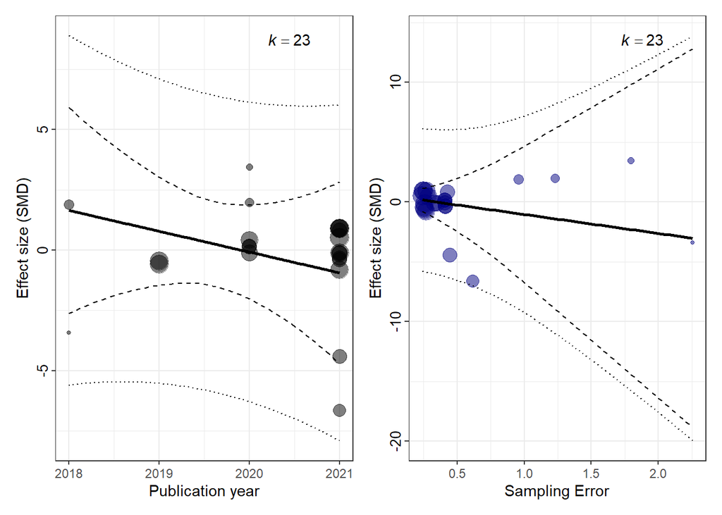

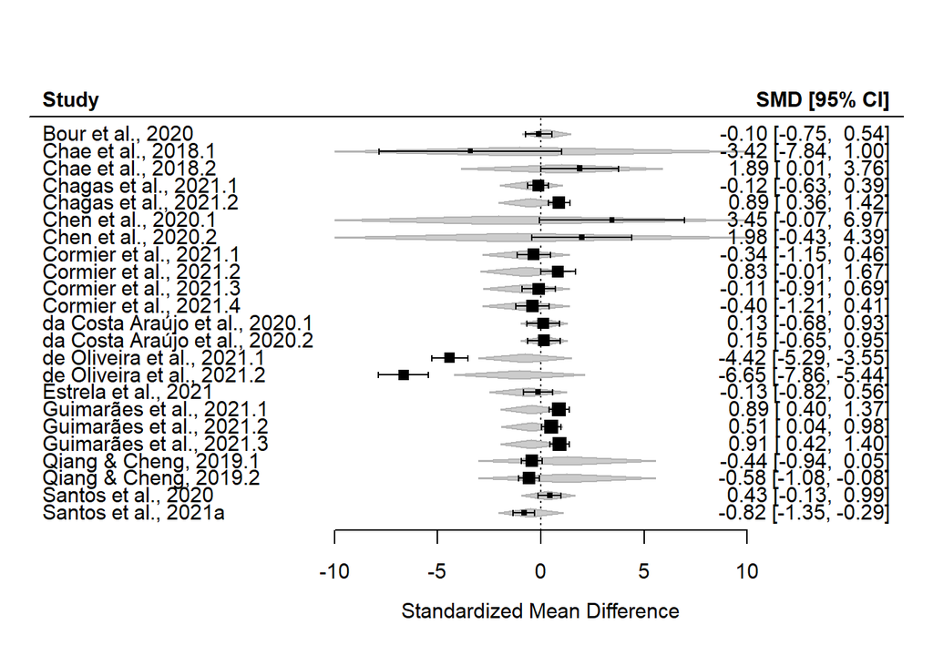

**Small-study effect** The regression slope of the extended Egger’s regression is $\sqrt{SMDSE} = -1.5858447$ is it statistically different from zero?`

If p<0.050: Smaller studies (with larger sampling error) have larger effect sizes –> small-study effect exists in this dataset. Data is assymmetrically distributed in the funnel plot.

If p>=0.050 no small-study effect exists in this dataset. Smaller studies (with larger sampling error) do not have larger effect sizes –> no small-study effect exists in this dataset. Data is symmetrically distributed in the funnel plot.

If p<0.050: studies with statistically significant findings tend to be published earlier than these with “negative” results, i.e. time-lag bias exists in this dataset

If p>=0.050: studies with statistically significant findings **do not** tend to be published earlier than these with “negative” results, i.e. no time-lag bias exists in this dataset

### Sensitivity analysis: publication bias with adapted SE

> Egger’s regression and its variants suffer from low power and poor performance when there are fewer than 20 effect sizes, or when the overall effect is large. (Nakagawa et al. 2022)

> Instead of the sample size (n1 + n2), however, for a meta-analysis of SMD or lnRR, we propose using the ‘effective sample size’ because it accounts for unbalanced sampling (cf. Stanley, 2005).(Nakagawa et al. 2022)

```r
if (mRE[[bias]]$pval[2] < 0.05) {

    # calculate modified SE based on effective sample size
    df$ess_vi <- with(df, sqrt((n_treat + n_ctrl)/(n_treat * n_ctrl)))
    df$ess_SE <- sqrt(df$ess_vi)  ## sampling error for ES

    # PET + year
    bias2 <- "PET sensitivity"
    mRE[[bias2]] <- rma.mv(yi, VCV, random = RE_formula, mods = ~ess_SE + Year, data = df,
        slab = Study, method = "REML", test = "t", dfs = "contain", level = 95)
    mRE[[bias2]] <- robust(mRE[[bias2]], cluster = df$Study, clubSandwich = TRUE)
    mRE[[bias2]] <- additional_results(mRE[[bias2]])
    mRE[[bias2]][["pi"]] <- predict(mRE[[bias2]], newmods = c(0, mean(df$Year)),
        digits = 2)

    # PEESE + year
    if (mRE[[bias2]]$pval[2] < 0.1) {
        mname <- "PEESE sensitivity"
        mRE[[mname]] <- rma.mv(yi, VCV, random = RE_formula, mods = ~ess_vi + Year,
            data = df, slab = Study, method = "REML", test = "t", dfs = "contain",
            level = 95)
        mRE[[mname]] <- robust(mRE[[mname]], cluster = df$Study, clubSandwich = TRUE)
        mRE[[mname]] <- additional_results(mRE[[mname]])
        mRE[[mname]][["pi"]] <- predict(mRE[[mname]], newmods = c(0, mean(df$Year)),
            digits = 2)
        bias2 <- mname
    }
}
```

If the results are the same, indicates the robustness of the small-study test.

#### Plots

# Sensitivity

## Rho range

```r
if (VCVrho != 0) {

    rho_range <- c(0, 0.25, 0.75, 0.9)  # assume a range values of rho

    for (j in 1:length(rho_range)) {

        mname <- paste("rho", rho_range[j], sep = "_")

        VCV2 <- vcalc(vi, cluster = interaction(df$EScluster, df$Study), obs = ESid,
            data = df, rho = rho_range[j])

        mRE[[mname]] <- rma.mv(yi, VCV2, random = RE_formula, data = df, slab = Study,
            method = "REML", test = "t", dfs = "contain", level = 95)
        mRE[[mname]] <- robust(mRE[[mname]], cluster = df$Study, clubSandwich = TRUE)
        mRE[[mname]] <- additional_results(mRE[[mname]])
    }
}
```

## Leave one out + Rho range

```r
if (VCVrho != 0) {
    rho_range <- c(0.25, 0.5, 0.75, 0.9)
} else {
    rho_range <- 0
}

for (i in sort(unique(df$Study))) {

    df_temp <- df[df$Study != i, ]

    for (j in 1:length(rho_range)) {

        mname <- paste("rho", rho_range[j], "l1o", i, sep = "_")
        print(mname)
        VCV2 <- vcalc(vi, cluster = interaction(df_temp$EScluster, df_temp$Study),
            obs = ESid, data = df_temp, rho = rho_range[j])

        mRE[[mname]] <- rma.mv(yi, VCV2, random = RE_formula, data = df_temp, slab = Study,
            method = "REML", test = "t", dfs = "contain", level = 95)
        mRE[[mname]] <- robust(mRE[[mname]], cluster = df_temp$Study, clubSandwich = TRUE)
        mRE[[mname]] <- additional_results(mRE[[mname]])
    }
}
```

```
[1] "rho_0.25_l1o_Bour et al., 2020"
[1] "rho_0.5_l1o_Bour et al., 2020"
[1] "rho_0.75_l1o_Bour et al., 2020"
[1] "rho_0.9_l1o_Bour et al., 2020"
[1] "rho_0.25_l1o_Chae et al., 2018"
[1] "rho_0.5_l1o_Chae et al., 2018"
[1] "rho_0.75_l1o_Chae et al., 2018"
[1] "rho_0.9_l1o_Chae et al., 2018"
[1] "rho_0.25_l1o_Chagas et al., 2021"
[1] "rho_0.5_l1o_Chagas et al., 2021"
[1] "rho_0.75_l1o_Chagas et al., 2021"
[1] "rho_0.9_l1o_Chagas et al., 2021"
[1] "rho_0.25_l1o_Chen et al., 2020"
[1] "rho_0.5_l1o_Chen et al., 2020"
[1] "rho_0.75_l1o_Chen et al., 2020"
```

[output cut: 33 more lines]

# Tables

|  | n studies | n ES clusters | n ES | overall effect | standard error | p-value | Lower CI | Upper CI | Lower PI | Upper PI | Q | Q p-value | $I^2$$_{total}$ | $I^2$$_{Study}$ | $I^2$$_{EScluster}$ | $I^2$$_{ES}$ | $\sigma^2$$_{Study}$ | $\sigma^2$$_{EScluster}$ | $\sigma^2$$_{ES}$ |
| --- | --- | --- | --- | --- | --- | --- | --- | --- | --- | --- | --- | --- | --- | --- | --- | --- | --- | --- | --- |
| ML | 12 | 17 | 23 | -0.20 | 0.5 | 0.7037 | -1.32 | 0.92 | -4.19 | 3.79 | 211.87 | 0 | 96.22 | 88.20 | 0.00 | 8.02 | 2.77 | 0.00 | 0.25 |
| ML_RobVar | 12 | 17 | 23 | -0.20 | 0.5 | 0.7037 | -1.32 | 0.93 | -4.19 | 3.79 | 211.87 | 0 | 96.22 | 88.20 | 0.00 | 8.02 | 2.77 | 0.00 | 0.25 |
| PET | 12 | 17 | 23 | 1742.14 | 1558.5 | 0.3397 | -3019.04 | 6503.32 | -4.54 | 5.62 | 209.26 | 0 | 96.91 | 91.44 | 0.00 | 5.48 | 3.52 | 0.00 | 0.21 |
| rho_0 | 12 | 17 | 23 | -0.20 | 0.5 | 0.7001 | -1.34 | 0.93 | -4.23 | 3.82 | 294.08 | 0 | 96.27 | 90.15 | 1.65 | 4.47 | 2.87 | 0.05 | 0.14 |
| rho_0.25 | 12 | 17 | 23 | -0.20 | 0.5 | 0.7022 | -1.33 | 0.93 | -4.21 | 3.81 | 241.27 | 0 | 96.25 | 90.03 | 0.00 | 6.21 | 2.85 | 0.00 | 0.20 |
| rho_0.75 | 12 | 17 | 23 | -0.20 | 0.5 | 0.7048 | -1.32 | 0.92 | -4.18 | 3.78 | 205.20 | 0 | 96.20 | 86.03 | 0.00 | 10.17 | 2.69 | 0.00 | 0.32 |
| rho_0.9 | 12 | 17 | 23 | -0.20 | 0.5 | 0.7052 | -1.31 | 0.92 | -4.18 | 3.78 | 247.47 | 0 | 96.20 | 84.63 | 0.00 | 11.57 | 2.64 | 0.00 | 0.36 |
| rho_0.25_l1o_Bour et al., 2020 | 11 | 16 | 22 | -0.21 | 0.6 | 0.7226 | -1.47 | 1.05 | -4.50 | 4.08 | 241.27 | 0 | 96.59 | 90.84 | 0.00 | 5.75 | 3.18 | 0.00 | 0.20 |
| rho_0.5_l1o_Bour et al., 2020 | 11 | 16 | 22 | -0.20 | 0.6 | 0.7239 | -1.46 | 1.05 | -4.48 | 4.07 | 211.87 | 0 | 96.56 | 89.16 | 0.00 | 7.41 | 3.10 | 0.00 | 0.26 |
| rho_0.75_l1o_Bour et al., 2020 | 11 | 16 | 22 | -0.20 | 0.6 | 0.7245 | -1.45 | 1.04 | -4.47 | 4.06 | 205.20 | 0 | 96.55 | 87.17 | 0.00 | 9.37 | 3.02 | 0.00 | 0.32 |
| rho_0.9_l1o_Bour et al., 2020 | 11 | 16 | 22 | -0.20 | 0.6 | 0.7247 | -1.44 | 1.04 | -4.46 | 4.06 | 247.47 | 0 | 96.55 | 85.89 | 0.00 | 10.66 | 2.97 | 0.00 | 0.37 |
| rho_0.25_l1o_Chae et al., 2018 | 11 | 15 | 21 | -0.29 | 0.5 | 0.6101 | -1.50 | 0.93 | -4.45 | 3.88 | 234.82 | 0 | 96.70 | 91.20 | 0.00 | 5.50 | 3.01 | 0.00 | 0.18 |
| rho_0.5_l1o_Chae et al., 2018 | 11 | 15 | 21 | -0.28 | 0.5 | 0.6141 | -1.49 | 0.93 | -4.43 | 3.87 | 205.37 | 0 | 96.68 | 89.52 | 0.00 | 7.16 | 2.93 | 0.00 | 0.23 |
| rho_0.75_l1o_Chae et al., 2018 | 11 | 15 | 21 | -0.28 | 0.5 | 0.6183 | -1.48 | 0.93 | -4.42 | 3.86 | 198.67 | 0 | 96.67 | 87.51 | 0.00 | 9.17 | 2.86 | 0.00 | 0.30 |
| rho_0.9_l1o_Chae et al., 2018 | 11 | 15 | 21 | -0.28 | 0.5 | 0.6207 | -1.48 | 0.93 | -4.42 | 3.87 | 240.90 | 0 | 96.67 | 86.19 | 0.00 | 10.48 | 2.82 | 0.00 | 0.34 |
| rho_0.25_l1o_Chagas et al., 2021 | 11 | 16 | 21 | -0.24 | 0.5 | 0.6714 | -1.46 | 0.98 | -4.38 | 3.90 | 226.53 | 0 | 96.11 | 90.16 | 4.06 | 1.89 | 2.95 | 0.13 | 0.06 |
| rho_0.5_l1o_Chagas et al., 2021 | 11 | 16 | 21 | -0.25 | 0.6 | 0.6673 | -1.49 | 0.99 | -4.45 | 3.96 | 193.22 | 0 | 96.23 | 90.42 | 0.00 | 5.81 | 3.05 | 0.00 | 0.20 |
| rho_0.75_l1o_Chagas et al., 2021 | 11 | 16 | 21 | -0.25 | 0.6 | 0.6658 | -1.49 | 0.99 | -4.47 | 3.97 | 173.40 | 0 | 96.25 | 87.78 | 0.00 | 8.47 | 2.98 | 0.00 | 0.29 |
| rho_0.9_l1o_Chagas et al., 2021 | 11 | 16 | 21 | -0.25 | 0.6 | 0.6650 | -1.49 | 0.99 | -4.47 | 3.98 | 174.69 | 0 | 96.26 | 86.22 | 0.00 | 10.04 | 2.94 | 0.00 | 0.34 |
| rho_0.25_l1o_Chen et al., 2020 | 11 | 15 | 21 | -0.39 | 0.5 | 0.4597 | -1.53 | 0.75 | -4.29 | 3.51 | 234.51 | 0 | 96.27 | 88.14 | 1.48 | 6.65 | 2.56 | 0.04 | 0.19 |
| rho_0.5_l1o_Chen et al., 2020 | 11 | 15 | 21 | -0.39 | 0.5 | 0.4605 | -1.52 | 0.74 | -4.28 | 3.50 | 205.03 | 0 | 96.25 | 87.39 | 0.00 | 8.86 | 2.53 | 0.00 | 0.26 |
| rho_0.75_l1o_Chen et al., 2020 | 11 | 15 | 21 | -0.39 | 0.5 | 0.4594 | -1.51 | 0.74 | -4.27 | 3.49 | 198.31 | 0 | 96.23 | 85.00 | 0.00 | 11.23 | 2.45 | 0.00 | 0.32 |
| rho_0.9_l1o_Chen et al., 2020 | 11 | 15 | 21 | -0.39 | 0.5 | 0.4586 | -1.51 | 0.73 | -4.26 | 3.49 | 240.52 | 0 | 96.22 | 83.44 | 0.00 | 12.78 | 2.40 | 0.00 | 0.37 |
| rho_0.25_l1o_Cormier et al., 2021 | 11 | 13 | 19 | -0.18 | 0.6 | 0.7600 | -1.46 | 1.10 | -4.62 | 4.26 | 235.73 | 0 | 97.02 | 22.55 | 68.96 | 5.52 | 0.85 | 2.59 | 0.21 |
| rho_0.5_l1o_Cormier et al., 2021 | 11 | 13 | 19 | -0.18 | 0.6 | 0.7609 | -1.45 | 1.10 | -4.61 | 4.26 | 206.26 | 0 | 97.02 | 22.50 | 67.11 | 7.41 | 0.84 | 2.51 | 0.28 |
| rho_0.75_l1o_Cormier et al., 2021 | 11 | 13 | 19 | -0.18 | 0.6 | 0.7612 | -1.45 | 1.09 | -4.62 | 4.26 | 199.55 | 0 | 97.02 | 22.48 | 65.03 | 9.51 | 0.84 | 2.44 | 0.36 |
| rho_0.9_l1o_Cormier et al., 2021 | 11 | 13 | 19 | -0.18 | 0.6 | 0.7613 | -1.45 | 1.09 | -4.62 | 4.26 | 241.75 | 0 | 97.03 | 22.47 | 63.74 | 10.82 | 0.84 | 2.39 | 0.41 |
| rho_0.25_l1o_da Costa Araújo et al., 2020 | 11 | 16 | 21 | -0.23 | 0.6 | 0.6904 | -1.50 | 1.03 | -4.55 | 4.09 | 240.75 | 0 | 96.73 | 89.71 | 0.00 | 7.02 | 3.18 | 0.00 | 0.25 |
| rho_0.5_l1o_da Costa Araújo et al., 2020 | 11 | 16 | 21 | -0.23 | 0.6 | 0.6912 | -1.49 | 1.03 | -4.54 | 4.08 | 211.38 | 0 | 96.72 | 87.91 | 0.00 | 8.81 | 3.10 | 0.00 | 0.31 |
| rho_0.75_l1o_da Costa Araújo et al., 2020 | 11 | 16 | 21 | -0.23 | 0.6 | 0.6917 | -1.49 | 1.03 | -4.53 | 4.07 | 204.74 | 0 | 96.71 | 85.87 | 0.00 | 10.84 | 3.02 | 0.00 | 0.38 |
| rho_0.9_l1o_da Costa Araújo et al., 2020 | 11 | 16 | 21 | -0.23 | 0.6 | 0.6919 | -1.48 | 1.02 | -4.53 | 4.07 | 246.99 | 0 | 96.71 | 84.58 | 0.00 | 12.13 | 2.97 | 0.00 | 0.43 |
| rho_0.25_l1o_de Oliveira et al., 2021 | 11 | 16 | 21 | 0.11 | 0.2 | 0.4866 | -0.25 | 0.48 | -1.13 | 1.36 | 68.54 | 0 | 69.19 | 0.00 | 48.89 | 20.30 | 0.00 | 0.18 | 0.07 |
| rho_0.5_l1o_de Oliveira et al., 2021 | 11 | 16 | 21 | 0.11 | 0.2 | 0.4879 | -0.25 | 0.48 | -1.13 | 1.36 | 68.80 | 0 | 69.28 | 0.00 | 44.78 | 24.50 | 0.00 | 0.16 | 0.09 |
| rho_0.75_l1o_de Oliveira et al., 2021 | 11 | 16 | 21 | 0.11 | 0.2 | 0.4895 | -0.25 | 0.48 | -1.14 | 1.36 | 82.47 | 0 | 69.35 | 0.00 | 40.82 | 28.53 | 0.00 | 0.15 | 0.10 |
| rho_0.9_l1o_de Oliveira et al., 2021 | 11 | 16 | 21 | 0.11 | 0.2 | 0.4906 | -0.25 | 0.48 | -1.14 | 1.36 | 132.67 | 0 | 69.37 | 0.00 | 38.53 | 30.84 | 0.00 | 0.14 | 0.11 |
| rho_0.25_l1o_Estrela et al., 2021 | 11 | 16 | 22 | -0.20 | 0.6 | 0.7257 | -1.46 | 1.05 | -4.49 | 4.08 | 241.26 | 0 | 96.61 | 90.86 | 0.00 | 5.75 | 3.18 | 0.00 | 0.20 |
| rho_0.5_l1o_Estrela et al., 2021 | 11 | 16 | 22 | -0.20 | 0.6 | 0.7270 | -1.45 | 1.05 | -4.47 | 4.07 | 211.87 | 0 | 96.58 | 89.18 | 0.00 | 7.41 | 3.10 | 0.00 | 0.26 |
| rho_0.75_l1o_Estrela et al., 2021 | 11 | 16 | 22 | -0.20 | 0.6 | 0.7276 | -1.45 | 1.05 | -4.46 | 4.06 | 205.20 | 0 | 96.57 | 87.19 | 0.00 | 9.38 | 3.02 | 0.00 | 0.32 |
| rho_0.9_l1o_Estrela et al., 2021 | 11 | 16 | 22 | -0.20 | 0.6 | 0.7278 | -1.44 | 1.04 | -4.46 | 4.06 | 247.47 | 0 | 96.57 | 85.91 | 0.00 | 10.66 | 2.97 | 0.00 | 0.37 |
| rho_0.25_l1o_Guimarães et al., 2021 | 11 | 16 | 20 | -0.30 | 0.6 | 0.6032 | -1.56 | 0.96 | -4.60 | 3.99 | 209.08 | 0 | 96.07 | 86.95 | 0.00 | 9.12 | 3.07 | 0.00 | 0.32 |
| rho_0.5_l1o_Guimarães et al., 2021 | 11 | 16 | 20 | -0.30 | 0.6 | 0.6033 | -1.55 | 0.95 | -4.58 | 3.98 | 186.32 | 0 | 96.05 | 85.21 | 0.00 | 10.84 | 2.99 | 0.00 | 0.38 |
| rho_0.75_l1o_Guimarães et al., 2021 | 11 | 16 | 20 | -0.30 | 0.6 | 0.6031 | -1.55 | 0.95 | -4.58 | 3.98 | 181.38 | 0 | 96.03 | 83.28 | 0.00 | 12.76 | 2.92 | 0.00 | 0.45 |
| rho_0.9_l1o_Guimarães et al., 2021 | 11 | 16 | 20 | -0.30 | 0.6 | 0.6029 | -1.54 | 0.94 | -4.57 | 3.97 | 216.80 | 0 | 96.03 | 82.05 | 0.00 | 13.98 | 2.87 | 0.00 | 0.49 |
| rho_0.25_l1o_Qiang & Cheng, 2019 | 11 | 16 | 21 | -0.17 | 0.6 | 0.7698 | -1.44 | 1.10 | -4.51 | 4.16 | 235.92 | 0 | 96.40 | 89.12 | 0.00 | 7.28 | 3.19 | 0.00 | 0.26 |
| rho_0.5_l1o_Qiang & Cheng, 2019 | 11 | 16 | 21 | -0.17 | 0.6 | 0.7714 | -1.44 | 1.10 | -4.49 | 4.15 | 207.66 | 0 | 96.38 | 87.46 | 0.00 | 8.92 | 3.11 | 0.00 | 0.32 |
| rho_0.75_l1o_Qiang & Cheng, 2019 | 11 | 16 | 21 | -0.17 | 0.6 | 0.7727 | -1.43 | 1.09 | -4.48 | 4.15 | 201.49 | 0 | 96.36 | 85.56 | 0.00 | 10.80 | 3.04 | 0.00 | 0.38 |
| rho_0.9_l1o_Qiang & Cheng, 2019 | 11 | 16 | 21 | -0.17 | 0.6 | 0.7733 | -1.42 | 1.09 | -4.48 | 4.14 | 243.39 | 0 | 96.36 | 84.35 | 0.00 | 12.01 | 2.99 | 0.00 | 0.43 |
| rho_0.25_l1o_Santos et al., 2020 | 11 | 16 | 22 | -0.26 | 0.6 | 0.6577 | -1.51 | 0.99 | -4.51 | 4.00 | 237.76 | 0 | 96.49 | 90.67 | 0.00 | 5.82 | 3.13 | 0.00 | 0.20 |
| rho_0.5_l1o_Santos et al., 2020 | 11 | 16 | 22 | -0.25 | 0.6 | 0.6589 | -1.50 | 0.99 | -4.50 | 3.99 | 208.10 | 0 | 96.46 | 88.96 | 0.00 | 7.50 | 3.05 | 0.00 | 0.26 |
| rho_0.75_l1o_Santos et al., 2020 | 11 | 16 | 22 | -0.25 | 0.6 | 0.6596 | -1.49 | 0.99 | -4.49 | 3.98 | 201.26 | 0 | 96.45 | 86.96 | 0.00 | 9.49 | 2.97 | 0.00 | 0.32 |
| rho_0.9_l1o_Santos et al., 2020 | 11 | 16 | 22 | -0.25 | 0.6 | 0.6599 | -1.49 | 0.98 | -4.48 | 3.98 | 243.35 | 0 | 96.44 | 85.66 | 0.00 | 10.79 | 2.92 | 0.00 | 0.37 |
| rho_0.25_l1o_Santos et al., 2021a | 11 | 16 | 22 | -0.14 | 0.6 | 0.8077 | -1.39 | 1.11 | -4.41 | 4.13 | 233.20 | 0 | 96.47 | 90.70 | 0.00 | 5.77 | 3.14 | 0.00 | 0.20 |
| rho_0.5_l1o_Santos et al., 2021a | 11 | 16 | 22 | -0.14 | 0.6 | 0.8092 | -1.38 | 1.11 | -4.39 | 4.11 | 204.06 | 0 | 96.44 | 89.00 | 0.00 | 7.44 | 3.06 | 0.00 | 0.26 |
| rho_0.75_l1o_Santos et al., 2021a | 11 | 16 | 22 | -0.14 | 0.6 | 0.8098 | -1.38 | 1.10 | -4.38 | 4.10 | 197.53 | 0 | 96.43 | 87.00 | 0.00 | 9.43 | 2.98 | 0.00 | 0.32 |
| rho_0.9_l1o_Santos et al., 2021a | 11 | 16 | 22 | -0.14 | 0.6 | 0.8099 | -1.37 | 1.10 | -4.37 | 4.10 | 240.00 | 0 | 96.42 | 85.71 | 0.00 | 10.72 | 2.93 | 0.00 | 0.37 |

|  | ML | ML_RobVar | PET | rho_0 | rho_0.25 | rho_0.75 | rho_0.9 | rho_0.25_l1o_Bour.et.al...2020 | rho_0.5_l1o_Bour.et.al...2020 | rho_0.75_l1o_Bour.et.al...2020 | rho_0.9_l1o_Bour.et.al...2020 | rho_0.25_l1o_Chae.et.al...2018 | rho_0.5_l1o_Chae.et.al...2018 | rho_0.75_l1o_Chae.et.al...2018 | rho_0.9_l1o_Chae.et.al...2018 | rho_0.25_l1o_Chagas.et.al...2021 | rho_0.5_l1o_Chagas.et.al...2021 | rho_0.75_l1o_Chagas.et.al...2021 | rho_0.9_l1o_Chagas.et.al...2021 | rho_0.25_l1o_Chen.et.al...2020 | rho_0.5_l1o_Chen.et.al...2020 | rho_0.75_l1o_Chen.et.al...2020 | rho_0.9_l1o_Chen.et.al...2020 | rho_0.25_l1o_Cormier.et.al...2021 | rho_0.5_l1o_Cormier.et.al...2021 | rho_0.75_l1o_Cormier.et.al...2021 | rho_0.9_l1o_Cormier.et.al...2021 | rho_0.25_l1o_da.Costa.Araújo.et.al...2020 | rho_0.5_l1o_da.Costa.Araújo.et.al...2020 | … |
| --- | --- | --- | --- | --- | --- | --- | --- | --- | --- | --- | --- | --- | --- | --- | --- | --- | --- | --- | --- | --- | --- | --- | --- | --- | --- | --- | --- | --- | --- | --- |
| logLik: | -39.08791182187542 | -39.08791182187542 | -34.17811336770959 | -38.68022380679575 | -38.87284842965141 | -39.31946823455631 | -39.45976231548033 | -37.33185011297877 | -37.55100075902169 | -37.78479856524942 | -37.92579237590642 | -33.04611827145744 | -33.30308238451376 | -33.58148385563996 | -33.75097832649084 | -35.55840493719744 | -35.9802081994867 | -36.29453879514949 | -36.46492897228687 | -34.34638379746946 | -34.55085832680832 | -34.76568269620012 | -34.89543952374962 | -33.73417103584589 | -33.93831678139594 | -34.13559171808659 | -34.24767451327276 | -36.61365979860589 | -36.81017787198368 | … |
| deviance: | 78.17582364375085 | 78.17582364375085 | 68.35622673541917 | 77.3604476135915 | 77.74569685930283 | 78.63893646911262 | 78.91952463096065 | 74.66370022595754 | 75.10200151804338 | 75.56959713049883 | 75.85158475181284 | 66.09223654291489 | 66.60616476902753 | 67.16296771127992 | 67.50195665298169 | 71.11680987439487 | 71.96041639897341 | 72.58907759029898 | 72.92985794457374 | 68.69276759493891 | 69.10171665361663 | 69.53136539240025 | 69.79087904749925 | 67.46834207169178 | 67.87663356279188 | 68.27118343617319 | 68.49534902654553 | 73.22731959721179 | 73.62035574396735 | … |
| AIC: | 86.17582364375085 | 86.17582364375085 | 80.35622673541917 | 85.3604476135915 | 85.74569685930283 | 86.63893646911262 | 86.91952463096065 | 82.66370022595754 | 83.10200151804338 | 83.56959713049883 | 83.85158475181284 | 74.09223654291489 | 74.60616476902753 | 75.16296771127992 | 75.50195665298169 | 79.11680987439487 | 79.96041639897341 | 80.58907759029898 | 80.92985794457374 | 76.69276759493891 | 77.10171665361663 | 77.53136539240025 | 77.79087904749925 | 75.46834207169178 | 75.87663356279188 | 76.27118343617319 | 76.49534902654553 | 81.22731959721179 | 81.62035574396735 | … |
| BIC: | 90.53999345718411 | 90.53999345718411 | 86.33062037674311 | 89.72461742702477 | 90.10986667273609 | 91.00310628254589 | 91.28369444439392 | 86.84178997685123 | 87.28009126893707 | 87.74768688139253 | 88.02967450270653 | 78.07516563713085 | 78.58909386324349 | 79.14589680549588 | 79.48488574719765 | 83.09973896861084 | 83.94334549318937 | 84.57200668451495 | 84.9127870387897 | 80.67569668915488 | 81.0846457478326 | 81.51429448661621 | 81.77380814171521 | 79.02982910327644 | 79.43812059437654 | 79.83267046775785 | 80.05683605813019 | 85.21024869142775 | 85.60328483818331 | … |
| AICc: | 88.52876482022144 | 88.52876482022144 | 86.81776519695762 | 87.7133887900621 | 88.09863803577342 | 88.99187764558322 | 89.27246580743125 | 85.16370022595754 | 85.60200151804338 | 86.06959713049883 | 86.35158475181284 | 76.75890320958156 | 77.2728314356942 | 77.82963437794659 | 78.16862331964836 | 81.78347654106155 | 82.62708306564008 | 83.25574425696566 | 83.59652461124041 | 79.35943426160559 | 79.7683833202833 | 80.19803205906692 | 80.45754571416592 | 78.54526514861486 | 78.95355663971496 | 79.34810651309627 | 79.5722721034686 | 83.89398626387846 | 84.28702241063402 | … |

# Influential cases

> Outliers and influential cases can actually reveal patterns that may lead to new insights about study characteristics that could be acting as potential moderators (Viechtbauer and Cheung 2010)

Cook’s distance: examine what effect the deletion of the ith study has on the fitted values of all k studies simultaneously (Viechtbauer and Cheung 2010)

DFBETAS: directly examine the influence of deleting the ith case on each individual parameter estimate (Viechtbauer and Cheung 2010)

So if a point has high Cook’s Distance, use DFBETAS to identify witch estimate is mainly influenced (only makes sense for meta regression).

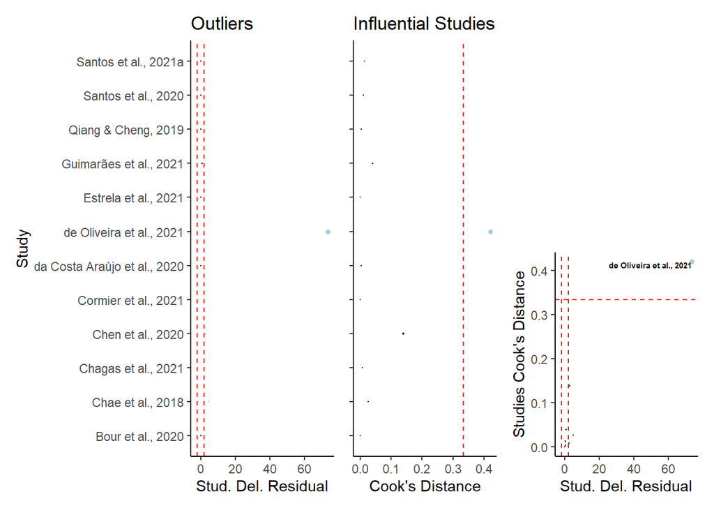

```r
influentialcases_plots(mRE, "ML_RobVar", "ML", 3)
```

# Multilevel meta-regression

SYRCLE PROTOCOL: Meta-regression will be used for outcomes with at least 10 experiments.

> The minimal number of studies or effect sizes required by a multilevel meta-regression remains unknown, albeit some simulation studies suggest that the estimates of model coefficients of a multilevel meta-regression are generally stable under various simulated situations.(Yang et al. 2023) … the complexity of parameterization of such a meta-regression requires a large dataset to make optimization algorithms free of convergence issues.(Yang et al. 2023)

## Model 1: Size, Duration, Development

```r
df_MR <- select(df, c("Year", "StudyID", "Study", "EScluster", "ESid", "DevelopmentalStage",
    "ExposureDurationDays", "ParticleSizeMean", "yi", "vi"))

mname1 <- "Base"
mname2 <- paste0(mname1, "_RobVar")

# are there differences between the different forms of DevelopmentalStage?
# mods_formula <- formula(~ ParticleSizeMean +
# ExposureDurationDays*DevelopmentalStage) at least one of the
# DevelopmentalStage levels is different than zero?
mods_formula <- formula(~0 + ParticleSizeMean + ExposureDurationDays * DevelopmentalStage)

mMR[[mname1]] <- rma.mv(yi, VCV, random = RE_formula, mods = mods_formula, data = df_MR,
    slab = Study, method = "REML", test = "t", dfs = "contain", level = 95)  #it will only keep complete cases

nSt_MR <- mMR[[mname1]]$s.nlevels[1]  # number of studies
nEC_MR <- mMR[[mname1]]$s.nlevels[2]  # number of ESclusters
nES_MR <- mMR[[mname1]]$s.nlevels[3]  # number of independent ES

print(paste0("Number of studies: ", nSt_MR, ", number of ES clusters: ", nEC_MR,
    " and number of independent observations of ES: ", nES_MR))
```

```
[1] "Number of studies: 12, number of ES clusters: 17 and number of independent observations of ES: 23"
```

```r
mMR[[mname2]] <- robust(mMR[[mname1]], cluster = df_MR$Study, clubSandwich = TRUE,
    verbose = TRUE)

mMR[[mname2]][["i2"]] <- i2_ml(mMR[[mname2]])
mMR[[mname2]][["icc"]] <- round(mMR[[mname2]]$sigma2/sum(mMR[[mname2]]$sigma2), 3)

anova(mMR[[mname2]], btt = c("DevelopmentalStage", "ExposureDurationDays", "ParticleSizeMean"))
```

```
                  spec coefs   Fval df1  df2   pval
1   DevelopmentalStage   3:7 1.7301   5 0.03 0.9416
2 ExposureDurationDays   2,7 0.1342   2 0.98 0.8882
3     ParticleSizeMean     1 3.5973   1 1.01 0.3078
```

The meta-regression comprised 23 comparisons from 17 control group clusters of 12 independent studies.

#### Diagnostics plots

```
Multivariate Meta-Analysis Model (k = 23; method: REML)

  logLik  Deviance       AIC       BIC      AICc
-27.3381   54.6763   74.6763   82.4022  118.6763

Variance Components:

            estim    sqrt  nlvls  fixed                factor
sigma^2.1  3.4831  1.8663     12     no                 Study
sigma^2.2  0.0000  0.0002     17     no       Study/EScluster
sigma^2.3  0.2903  0.5388     23     no  Study/EScluster/ESid

Test for Residual Heterogeneity:
QE(df = 16) = 159.1947, p-val < .0001

Number of estimates:   23
Number of clusters:    12
Estimates per cluster: 0-4 (mean: 0.39, median: 0)

Test of Moderators (coefficients 1:7):¹
F(df1 = 7, df2 = 0) = 0.0000, p-val = NA

Model Results:

                                              estimate      se¹     tval¹
ParticleSizeMean                               -0.0028  0.0015   -1.8967
ExposureDurationDays                           -0.0068  0.0095   -0.7101
DevelopmentalStageLarva                        -2.0194  2.9625   -0.6817
DevelopmentalStageJuvenile                     -0.1107  0.0286   -3.8686
DevelopmentalStageAdult                         0.8872  0.5195    1.7078
DevelopmentalStageUnclear                       0.9031  0.1962    4.6037
ExposureDurationDays:DevelopmentalStageLarva    0.0758  0.3482    0.2177
                                                df¹    pval¹     ci.lb¹
ParticleSizeMean                              1.01   0.3078    -0.0213
ExposureDurationDays                          1.47   0.5731    -0.0656
DevelopmentalStageLarva                       1.76   0.5740   -16.5888
DevelopmentalStageJuvenile                    1.47   0.0967    -0.2874
DevelopmentalStageAdult                       3.84   0.1659    -0.5797
DevelopmentalStageUnclear                      1.6   0.0663    -0.1834
ExposureDurationDays:DevelopmentalStageLarva  1.21   0.8586    -2.8981
                                                ci.ub¹
ParticleSizeMean                               0.0157
ExposureDurationDays                           0.0521
DevelopmentalStageLarva                       12.5500
DevelopmentalStageJuvenile                     0.0660   .
DevelopmentalStageAdult                        2.3542
DevelopmentalStageUnclear                      1.9896   .
ExposureDurationDays:DevelopmentalStageLarva   3.0496

---
Signif. codes:  0 '***' 0.001 '**' 0.01 '*' 0.05 '.' 0.1 ' ' 1

1) results based on cluster-robust inference (var-cov estimator: CR2,
   approx t/F-tests and confidence intervals, df: Satterthwaite approx)
```

|  | ML | REML |
| --- | --- | --- |
| ll | -39.20980 | -27.33814 |
| dev | 76.71126 | 54.67628 |
| AIC | 98.41961 | 74.67628 |
| BIC | 109.77455 | 82.40217 |
| AICc | 116.75294 | 118.67628 |

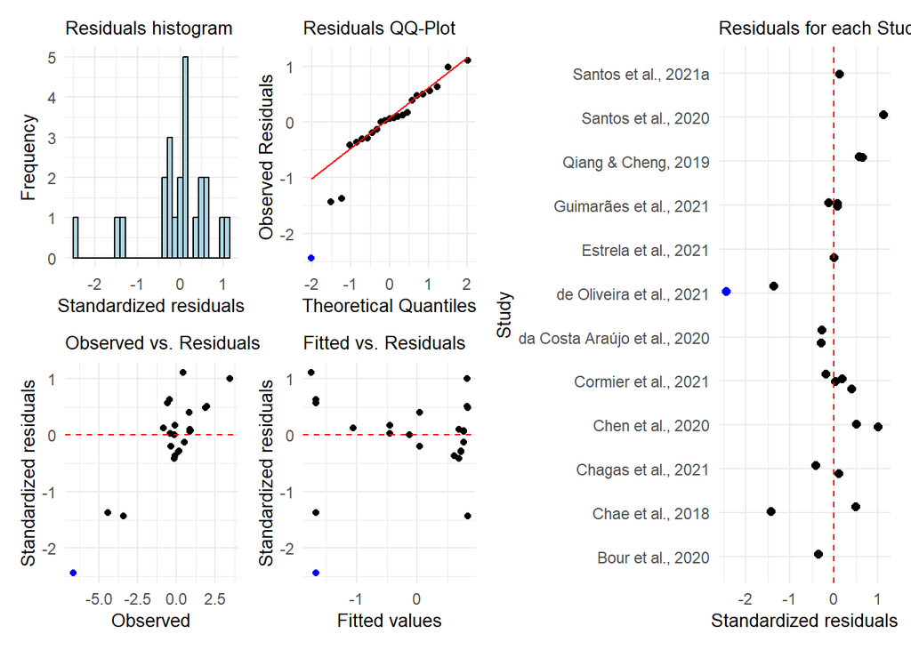

#### Influential cases

```
           Bour et al., 2020            Chae et al., 2018
                8.008566e-01                 4.366992e-03
         Chagas et al., 2021            Chen et al., 2020
                2.382138e-01                 1.111582e+00
        Cormier et al., 2021 da Costa Araújo et al., 2020
                4.654269e+03                 3.318389e-01
    de Oliveira et al., 2021         Estrela et al., 2021
                3.864101e+00                           NA
      Guimarães et al., 2021          Qiang & Cheng, 2019
                          NA                 1.176081e-01
         Santos et al., 2020         Santos et al., 2021a
                5.244223e-01                 1.289475e+02
```

[figure not shown]

#### Orchard plots

(Nakagawa et al. 2021)

## Model 2: + Concentration

```r
df_MR <- select(df, c("Year", "StudyID", "Study", "EScluster", "ESid", "DevelopmentalStage",
    "ExposureDurationDays", "ParticleSizeMean", "Concentration_mg_L", "yi", "vi"))

mname1 <- "Conc+"
mname2 <- paste0(mname1, "_RobVar")

mods_formula <- formula(~0 + ParticleSizeMean + Concentration_mg_L + ExposureDurationDays *
    DevelopmentalStage)

mMR[[mname1]] <- rma.mv(yi, VCV, random = RE_formula, mods = mods_formula, data = df_MR,
    slab = Study, method = "REML", test = "t", dfs = "contain", level = 95)  #it will only keep complete cases

nSt_MR <- mMR[[mname1]]$s.nlevels[1]  # number of studies
nEC_MR <- mMR[[mname1]]$s.nlevels[2]  # number of ESclusters
nES_MR <- mMR[[mname1]]$s.nlevels[3]  # number of independent ES

print(paste0("Number of studies: ", nSt_MR, ", number of ES clusters: ", nEC_MR,
    " and number of independent observations of ES: ", nES_MR))
```

```
[1] "Number of studies: 10, number of ES clusters: 12 and number of independent observations of ES: 17"
```

```r
mMR[[mname2]] <- robust(mMR[[mname1]], cluster = df_MR$Study, clubSandwich = TRUE,
    verbose = TRUE)
```

```
Error in Wald_testing(C_mat = constraints, beta = beta, vcov = vcov, test = test,  :
  Variance-covariance matrix of the contrast is not positive definite. The test cannot be computed.
```

```r
mMR[[mname2]][["i2"]] <- i2_ml(mMR[[mname2]])
mMR[[mname2]][["icc"]] <- round(mMR[[mname2]]$sigma2/sum(mMR[[mname2]]$sigma2), 3)

anova(mMR[[mname2]], btt = c("DevelopmentalStage", "ExposureDurationDays", "ParticleSizeMean",
    "Concentration_mg_L"))
```

```
                  spec coefs   Fval df1   df2   pval
1   DevelopmentalStage   4:8 0.0000   5 -0.61     NA
2 ExposureDurationDays   3,8 0.0239   2  0.70 0.9772
3     ParticleSizeMean     1 0.0076   1  1.37 0.9414
4   Concentration_mg_L     2 0.0044   1  1.04 0.9576
```

The meta-regression comprised 17 comparisons from 12 control group clusters of 10 independent studies.

#### Diagnostics plots

```
Multivariate Meta-Analysis Model (k = 17; method: REML)

  logLik  Deviance       AIC       BIC      AICc
-17.8250   35.6499   57.6499   59.8194  321.6499

Variance Components:

            estim    sqrt  nlvls  fixed                factor
sigma^2.1  3.8567  1.9639     10     no                 Study
sigma^2.2  3.4934  1.8691     12     no       Study/EScluster
sigma^2.3  0.5600  0.7483     17     no  Study/EScluster/ESid

Test for Residual Heterogeneity:
QE(df = 9) = 151.6886, p-val < .0001

Number of estimates:   17
Number of clusters:    10
Estimates per cluster: 0-3 (mean: 0.29, median: 0)

Model Results:

                                              estimate      se¹     tval¹
ParticleSizeMean                               -0.0113  0.1296   -0.0873
Concentration_mg_L                             -0.0034  0.0510   -0.0662
ExposureDurationDays                           -0.0408  0.1514   -0.2697
DevelopmentalStageLarva                        -2.0651  3.0339   -0.6807
DevelopmentalStageJuvenile                     -0.0058  0.4562   -0.0126
DevelopmentalStageAdult                         1.5158  2.2055    0.6873
DevelopmentalStageUnclear                       1.6233  3.0742    0.5280
ExposureDurationDays:DevelopmentalStageLarva    0.1149  0.3881    0.2962
                                                df¹    pval¹     ci.lb¹
ParticleSizeMean                              1.37   0.9414    -0.9004
Concentration_mg_L                            1.04   0.9576    -0.5973
ExposureDurationDays                          1.08   0.8296    -1.6516
DevelopmentalStageLarva                       1.77   0.5741   -16.8841
DevelopmentalStageJuvenile                    1.08   0.9918    -4.8411
DevelopmentalStageAdult                       1.04   0.6130   -24.0675
DevelopmentalStageUnclear                     1.09   0.6847   -30.4672
ExposureDurationDays:DevelopmentalStageLarva   1.6   0.8010    -2.0282
                                                ci.ub¹
ParticleSizeMean                               0.8777
Concentration_mg_L                             0.5905
ExposureDurationDays                           1.5700
DevelopmentalStageLarva                       12.7538
DevelopmentalStageJuvenile                     4.8296
DevelopmentalStageAdult                       27.0990
DevelopmentalStageUnclear                     33.7137
ExposureDurationDays:DevelopmentalStageLarva   2.2581

---
Signif. codes:  0 '***' 0.001 '**' 0.01 '*' 0.05 '.' 0.1 ' ' 1

1) results based on cluster-robust inference (var-cov estimator: CR2,
   approx t/F-tests and confidence intervals, df: Satterthwaite approx)
```

|  | ML | REML |
| --- | --- | --- |
| ll | -33.67431 | -17.82497 |
| dev | 65.34008 | 35.64995 |
| AIC | 89.34863 | 57.64995 |
| BIC | 98.51397 | 59.81942 |
| AICc | 142.14863 | 321.64995 |

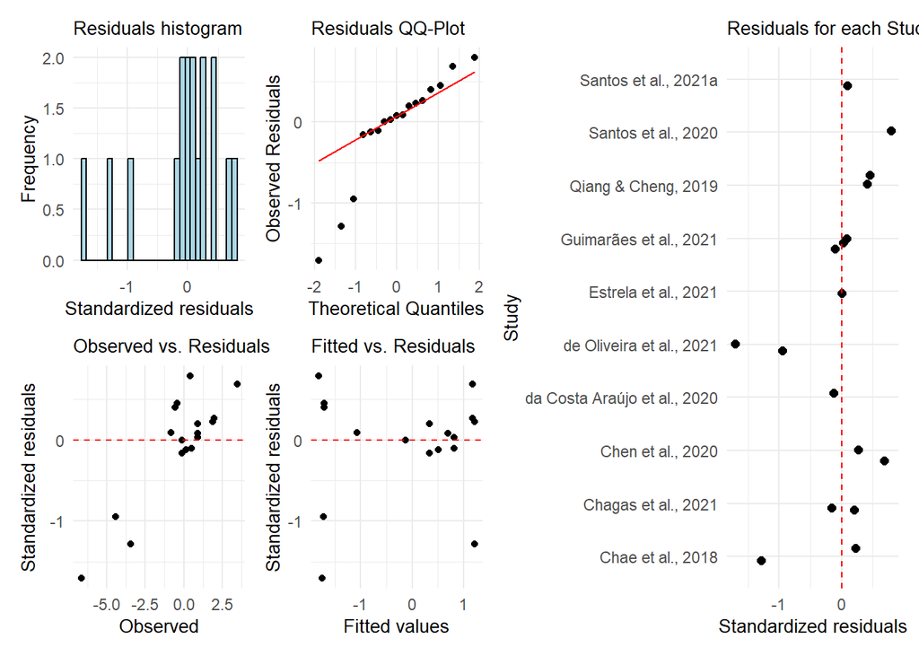

#### Influential cases

#### Orchard plots

## Model 3: + ParticleMaterial

```r
df_MR <- select(df, c("Year", "StudyID", "Study", "EScluster", "ESid", "DevelopmentalStage",
    "ExposureDurationDays", "ParticleSizeMean", "ParticleMaterial", "yi", "vi"))

mname1 <- "PartMat+"
mname2 <- paste0(mname1, "_RobVar")

mods_formula <- formula(~(ParticleSizeMean + ExposureDurationDays * DevelopmentalStage +
    ParticleMaterial))

mMR[[mname1]] <- rma.mv(yi, VCV, random = RE_formula, mods = mods_formula, data = df_MR,
    slab = Study, method = "REML", test = "t", dfs = "contain", level = 95)  #it will only keep complete cases

nSt_MR <- mMR[[mname1]]$s.nlevels[1]  # number of studies
nEC_MR <- mMR[[mname1]]$s.nlevels[2]  # number of ESclusters
nES_MR <- mMR[[mname1]]$s.nlevels[3]  # number of independent ES

print(paste0("Number of studies: ", nSt_MR, ", number of ES clusters: ", nEC_MR,
    " and number of independent observations of ES: ", nES_MR))
```

```
[1] "Number of studies: 12, number of ES clusters: 17 and number of independent observations of ES: 23"
```

```r
mMR[[mname2]] <- mMR[[mname1]]

mMR[[mname2]][["i2"]] <- i2_ml(mMR[[mname2]])
mMR[[mname2]][["icc"]] <- round(mMR[[mname2]]$sigma2/sum(mMR[[mname2]]$sigma2), 3)

anova(mMR[[mname2]], btt = c("DevelopmentalStage", "ExposureDurationDays", "ParticleSizeMean",
    "ParticleMaterial"))
```

```
                  spec  coefs   Fval df1 df2   pval
1   DevelopmentalStage 4:6,11 2.7258   4   1 0.4226
2 ExposureDurationDays   3,11 0.2534   2   1 0.8147
3     ParticleSizeMean      2 0.4551   1   1 0.6222
4     ParticleMaterial   7:10 2.9083   4   1 0.4109
```

The meta-regression comprised 23 comparisons from 17 control group clusters of 12 independent studies.

#### Diagnostics plots

```
Multivariate Meta-Analysis Model (k = 23; method: REML)

  logLik  Deviance       AIC       BIC      AICc
-18.2998   36.5997   64.5997   71.3884  484.5997

Variance Components:

            estim    sqrt  nlvls  fixed                factor
sigma^2.1  1.1280  1.0621     12     no                 Study
sigma^2.2  0.0917  0.3028     17     no       Study/EScluster
sigma^2.3  0.3000  0.5477     23     no  Study/EScluster/ESid

Test for Residual Heterogeneity:
QE(df = 12) = 56.7507, p-val < .0001

Test of Moderators (coefficients 2:11):
F(df1 = 10, df2 = 1) = 1.9654, p-val = 0.5080

Model Results:

                                              estimate      se     tval  df
intrcpt                                         2.4421  1.9658   1.2423   1
ParticleSizeMean                               -0.0029  0.0043  -0.6746   6
ExposureDurationDays                            0.0019  0.0146   0.1329   1
DevelopmentalStageLarva                        -1.5033  1.8307  -0.8212   1
DevelopmentalStageJuvenile                     -0.8659  1.7510  -0.4945   1
DevelopmentalStageAdult                         1.6235  1.5102   1.0750   1
ParticleMaterialPE                             -4.0744  1.8723  -2.1762   6
ParticleMaterialPLA                            -4.6293  1.5648  -2.9583   1
ParticleMaterialPS                             -1.7130  1.5411  -1.1115   1
ParticleMaterialPVC                            -3.6703  2.0180  -1.8187   6
ExposureDurationDays:DevelopmentalStageLarva   -0.1269  0.1793  -0.7078   1
                                                pval     ci.lb    ci.ub
intrcpt                                       0.4315  -22.5359  27.4201
ParticleSizeMean                              0.5251   -0.0133   0.0076
ExposureDurationDays                          0.9159   -0.1832   0.1870
DevelopmentalStageLarva                       0.5623  -24.7641  21.7576
DevelopmentalStageJuvenile                    0.7076  -23.1148  21.3829
DevelopmentalStageAdult                       0.4770  -17.5654  20.8123
ParticleMaterialPE                            0.0724   -8.6557   0.5068  .
ParticleMaterialPLA                           0.2075  -24.5126  15.2540
ParticleMaterialPS                            0.4664  -21.2951  17.8691
ParticleMaterialPVC                           0.1188   -8.6082   1.2677
ExposureDurationDays:DevelopmentalStageLarva  0.6079   -2.4053   2.1514

---
Signif. codes:  0 '***' 0.001 '**' 0.01 '*' 0.05 '.' 0.1 ' ' 1
```

|  | ML | REML |
| --- | --- | --- |
| ll | -32.31842 | -18.29984 |
| dev | 62.92848 | 36.59967 |
| AIC | 92.63683 | 64.59967 |
| BIC | 108.53375 | 71.38836 |
| AICc | 145.13683 | 484.59967 |

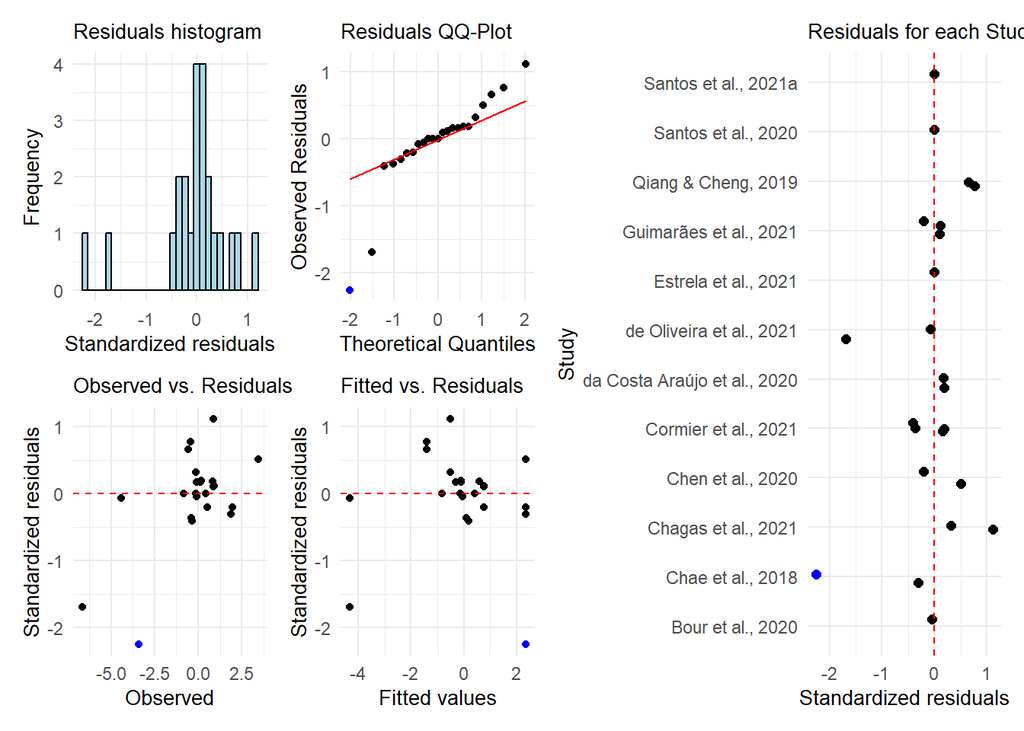

#### Influential cases

```
           Bour et al., 2020            Chae et al., 2018
                  0.01279537                   2.01766660
         Chagas et al., 2021            Chen et al., 2020
                  6.50784137                   0.08596743
        Cormier et al., 2021 da Costa Araújo et al., 2020
                          NA                   0.15658190
    de Oliveira et al., 2021         Estrela et al., 2021
                          NA                           NA
      Guimarães et al., 2021          Qiang & Cheng, 2019
                          NA                   6.96642181
         Santos et al., 2020         Santos et al., 2021a
                          NA                           NA
```

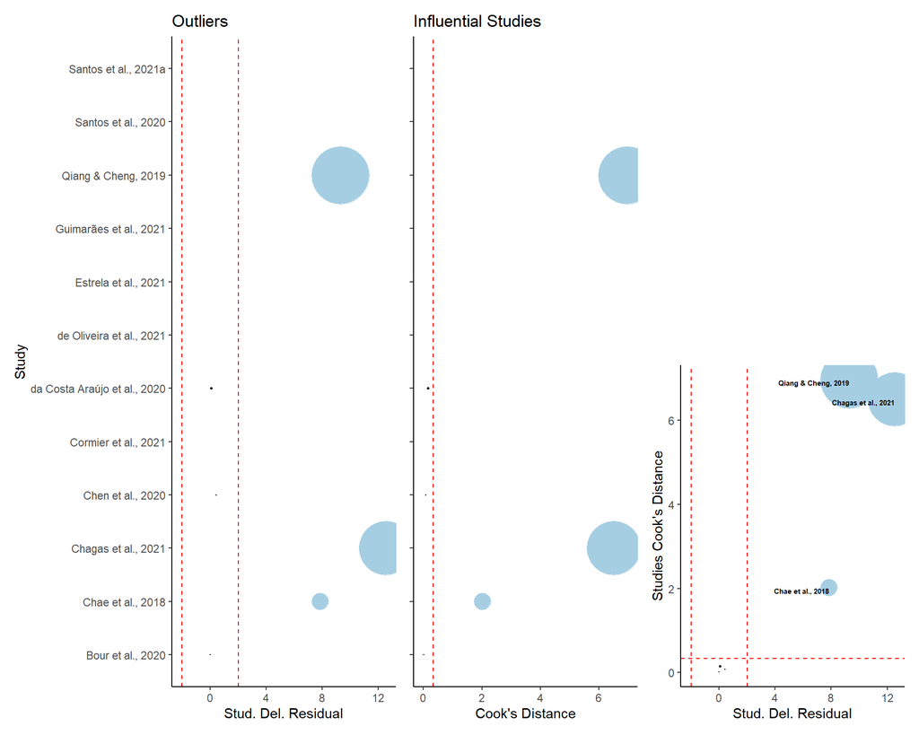

#### Orchard plots

# Referências

Harrer, Mathias, Pim Cuijpers, Toshi A. Furukawa, and David D. Ebert. n.d. *Chapter 9 Publication Bias | Doing Meta-Analysis in R*. https://bookdown.org/MathiasHarrer/Doing_Meta_Analysis_in_R/pub-bias.html.

Nakagawa, Shinichi, Malgorzata Lagisz, Michael D. Jennions, Julia Koricheva, Daniel W. A. Noble, Timothy H. Parker, Alfredo Sánchez-Tójar, Yefeng Yang, and Rose E. O’Dea. 2022. “Methods for Testing Publication Bias in Ecological and Evolutionary Meta-Analyses.” *Methods in Ecology and Evolution* 13 (1): 4–21. https://doi.org/10.1111/2041-210X.13724.

Nakagawa, Shinichi, Malgorzata Lagisz, Rose E. O’Dea, Joanna Rutkowska, Yefeng Yang, Daniel W. A. Noble, and Alistair M. Senior. 2021. “The Orchard Plot: Cultivating a Forest Plot for Use in Ecology, Evolution, and Beyond.” *Research Synthesis Methods* 12 (1): 4–12. https://doi.org/10.1002/jrsm.1424.

Stanley, T. D. 2017. “Limitations of PET-PEESE and Other Meta-Analysis Methods.” *Social Psychological and Personality Science* 8 (5): 581–91. https://doi.org/10.1177/1948550617693062.

Viechtbauer, Wolfgang. 2010. “Conducting Meta-Analyses in R with the Metafor Package.” *Journal of Statistical Software* 36 (August): 1–48. https://doi.org/10.18637/jss.v036.i03.

———. 2022. “Konstantopoulos (2011) [the Metafor Package].” https://www.metafor-project.org/doku.php/analyses:konstantopoulos2011.

Viechtbauer, Wolfgang, and Mike W.-L. Cheung. 2010. “Outlier and Influence Diagnostics for Meta-Analysis.” *Research Synthesis Methods* 1 (2): 112–25. https://doi.org/10.1002/jrsm.11.

Yang, Yefeng, Malcolm Macleod, Jinming Pan, Malgorzata Lagisz, and Shinichi Nakagawa. 2023. “Advanced Methods and Implementations for the Meta-Analyses of Animal Models: Current Practices and Future Recommendations.” *Neuroscience & Biobehavioral Reviews* 146 (March): 105016. https://doi.org/10.1016/j.neubiorev.2022.105016.